# Smoking Status Prediction

2023-03-13

****************************************Load Data*******************************************************

```r
path<- 'C:/Users/TSL/Documents/APU/Applied Machine Learning/assignment'
setwd(path)
```

************************************************library******************************************************

```r
library(dplyr)
library(DataExplorer)
library(doParallel)
library(missForest)
library(missMethods)
library(VIM)
library(caret)
```

```r
library(rpart)
library(rpart.plot)
library(ROCR)
library(ggplot2)
library(party)
library(tree)
library(randomForest)
library(caTools)
```

This dataset is a collection of basic health biological signal data. The goal is to determine the presence or absence of smoking through bio-signals.

```r
df= read.csv('smoking.csv',stringsAsFactors = TRUE)
```

**************************************Exploratory Data Analysis****************************************

#check data summary

```r
summary(df)
```

```
##        ID        gender         age          height.cm.      weight.kg.
##  Min.   :    0   F:20291   Min.   :20.00   Min.   :130.0   Min.   : 30.00
##  1st Qu.:13923   M:35401   1st Qu.:40.00   1st Qu.:160.0   1st Qu.: 55.00
##  Median :27846             Median :40.00   Median :165.0   Median : 65.00
##  Mean   :27846             Mean   :44.18   Mean   :164.6   Mean   : 65.86
##  3rd Qu.:41768             3rd Qu.:55.00   3rd Qu.:170.0   3rd Qu.: 75.00
##  Max.   :55691             Max.   :85.00   Max.   :190.0   Max.   :135.00
##    waist.cm.      eyesight.left.  eyesight.right. hearing.left.
##  Min.   : 51.00   Min.   :0.100   Min.   :0.100   Min.   :1.000
##  1st Qu.: 76.00   1st Qu.:0.800   1st Qu.:0.800   1st Qu.:1.000
##  Median : 82.00   Median :1.000   Median :1.000   Median :1.000
##  Mean   : 82.05   Mean   :1.013   Mean   :1.007   Mean   :1.026
##  3rd Qu.: 88.00   3rd Qu.:1.200   3rd Qu.:1.200   3rd Qu.:1.000
##  Max.   :129.00   Max.   :9.900   Max.   :9.900   Max.   :2.000
##  hearing.right.     systolic       relaxation  fasting.blood.sugar
##  Min.   :1.000   Min.   : 71.0   Min.   : 40   Min.   : 46.00
##  1st Qu.:1.000   1st Qu.:112.0   1st Qu.: 70   1st Qu.: 89.00
##  Median :1.000   Median :120.0   Median : 76   Median : 96.00
##  Mean   :1.026   Mean   :121.5   Mean   : 76   Mean   : 99.31
##  3rd Qu.:1.000   3rd Qu.:130.0   3rd Qu.: 82   3rd Qu.:104.00
##  Max.   :2.000   Max.   :240.0   Max.   :146   Max.   :505.00
##   Cholesterol     triglyceride        HDL              LDL
##  Min.   : 55.0   Min.   :  8.0   Min.   :  4.00   Min.   :   1
##  1st Qu.:172.0   1st Qu.: 74.0   1st Qu.: 47.00   1st Qu.:  92
##  Median :195.0   Median :108.0   Median : 55.00   Median : 113
##  Mean   :196.9   Mean   :126.7   Mean   : 57.29   Mean   : 115
##  3rd Qu.:220.0   3rd Qu.:160.0   3rd Qu.: 66.00   3rd Qu.: 136
##  Max.   :445.0   Max.   :999.0   Max.   :618.00   Max.   :1860
##    hemoglobin    Urine.protein   serum.creatinine       AST
##  Min.   : 4.90   Min.   :1.000   Min.   : 0.1000   Min.   :   6.00
##  1st Qu.:13.60   1st Qu.:1.000   1st Qu.: 0.8000   1st Qu.:  19.00
##  Median :14.80   Median :1.000   Median : 0.9000   Median :  23.00
##  Mean   :14.62   Mean   :1.087   Mean   : 0.8857   Mean   :  26.18
##  3rd Qu.:15.80   3rd Qu.:1.000   3rd Qu.: 1.0000   3rd Qu.:  28.00
##  Max.   :21.10   Max.   :6.000   Max.   :11.6000   Max.   :1311.00
##       ALT               Gtp         oral      dental.caries    tartar
##  Min.   :   1.00   Min.   :  1.00   Y:55692   Min.   :0.0000   N:24752
##  1st Qu.:  15.00   1st Qu.: 17.00             1st Qu.:0.0000   Y:30940
##  Median :  21.00   Median : 25.00             Median :0.0000
##  Mean   :  27.04   Mean   : 39.95             Mean   :0.2133
##  3rd Qu.:  31.00   3rd Qu.: 43.00             3rd Qu.:0.0000
##  Max.   :2914.00   Max.   :999.00             Max.   :1.0000
##     smoking
##  Min.   :0.0000
##  1st Qu.:0.0000
##  Median :0.0000
##  Mean   :0.3673
##  3rd Qu.:1.0000
##  Max.   :1.0000
```

#Check data structure

```r
str(df)
```

```
## 'data.frame':    55692 obs. of  27 variables:
##  $ ID                 : int  0 1 2 3 4 5 6 7 9 10 ...
##  $ gender             : Factor w/ 2 levels "F","M": 1 1 2 2 1 2 2 2 1 2 ...
##  $ age                : int  40 40 55 40 40 30 40 45 50 45 ...
##  $ height.cm.         : int  155 160 170 165 155 180 160 165 150 175 ...
##  $ weight.kg.         : int  60 60 60 70 60 75 60 90 60 75 ...
##  $ waist.cm.          : num  81.3 81 80 88 86 85 85.5 96 85 89 ...
##  $ eyesight.left.     : num  1.2 0.8 0.8 1.5 1 1.2 1 1.2 0.7 1 ...
##  $ eyesight.right.    : num  1 0.6 0.8 1.5 1 1.2 1 1 0.8 1 ...
##  $ hearing.left.      : num  1 1 1 1 1 1 1 1 1 1 ...
##  $ hearing.right.     : num  1 1 1 1 1 1 1 1 1 1 ...
##  $ systolic           : num  114 119 138 100 120 128 116 153 115 113 ...
##  $ relaxation         : num  73 70 86 60 74 76 82 96 74 64 ...
##  $ fasting.blood.sugar: num  94 130 89 96 80 95 94 158 86 94 ...
##  $ Cholesterol        : num  215 192 242 322 184 217 226 222 210 198 ...
##  $ triglyceride       : num  82 115 182 254 74 199 68 269 66 147 ...
##  $ HDL                : num  73 42 55 45 62 48 55 34 48 43 ...
##  $ LDL                : num  126 127 151 226 107 129 157 134 149 126 ...
##  $ hemoglobin         : num  12.9 12.7 15.8 14.7 12.5 16.2 17 15 13.7 16 ...
##  $ Urine.protein      : num  1 1 1 1 1 1 1 1 1 1 ...
##  $ serum.creatinine   : num  0.7 0.6 1 1 0.6 1.2 0.7 1.3 0.8 0.8 ...
##  $ AST                : num  18 22 21 19 16 18 21 38 31 26 ...
##  $ ALT                : num  19 19 16 26 14 27 27 71 31 24 ...
##  $ Gtp                : num  27 18 22 18 22 33 39 111 14 63 ...
##  $ oral               : Factor w/ 1 level "Y": 1 1 1 1 1 1 1 1 1 1 ...
##  $ dental.caries      : int  0 0 0 0 0 0 1 0 0 0 ...
##  $ tartar             : Factor w/ 2 levels "N","Y": 2 2 1 2 1 2 2 2 1 1 ...
##  $ smoking            : int  0 0 1 0 0 0 1 0 0 0 ...
```

#check unique values in columns

```r
sapply(df, function(x) n_distinct(x))
```

```
##                  ID              gender                 age          height.cm.
##               55692                   2                  14                  13
##          weight.kg.           waist.cm.      eyesight.left.     eyesight.right.
##                  22                 566                  19                  17
##       hearing.left.      hearing.right.            systolic          relaxation
##                   2                   2                 130                  95
## fasting.blood.sugar         Cholesterol        triglyceride                 HDL
##                 276                 286                 390                 126
##                 LDL          hemoglobin       Urine.protein    serum.creatinine
##                 289                 145                   6                  38
##                 AST                 ALT                 Gtp                oral
##                 219                 245                 488                   1
##       dental.caries              tartar             smoking
##                   2                   2                   2
```

#Plot graphs for data visualization

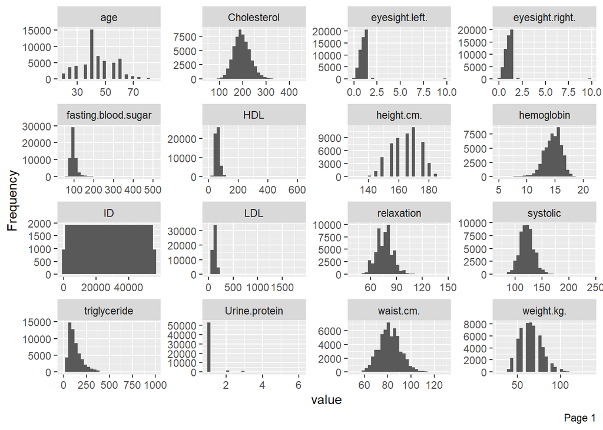

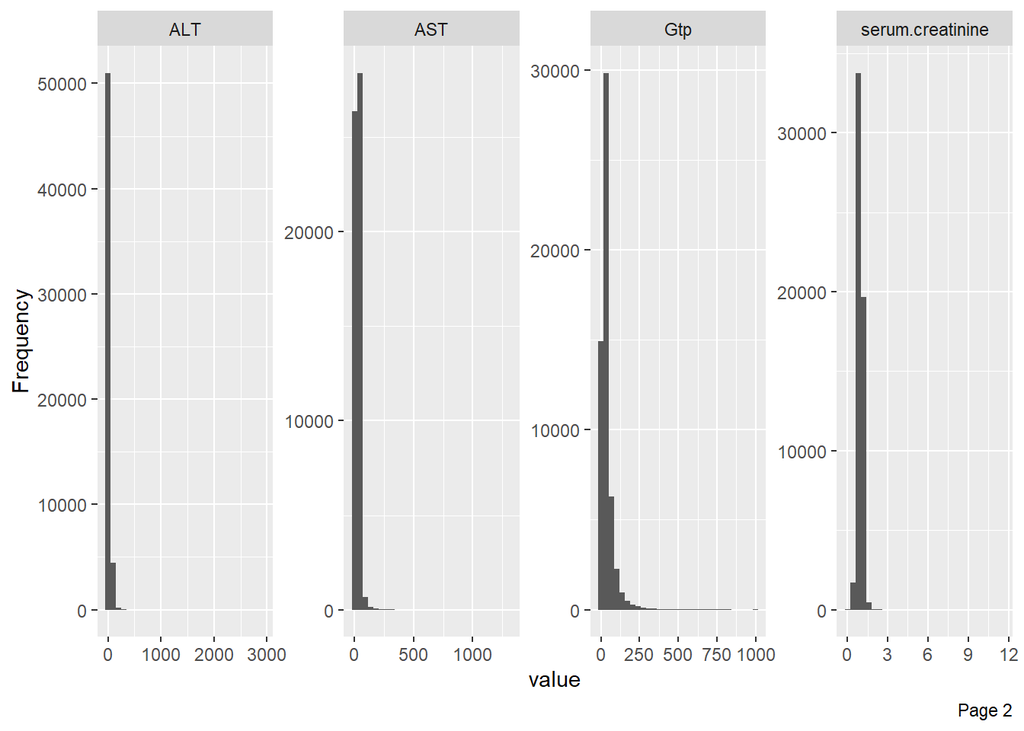

```r
library(DataExplorer)
plot_histogram(df)
```

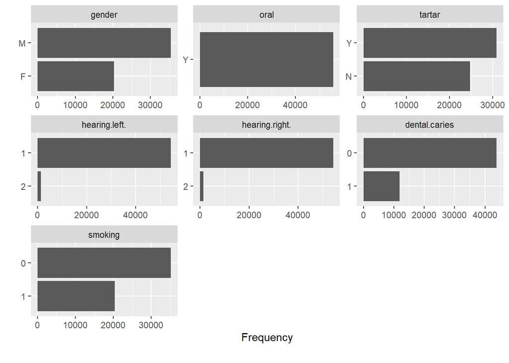

```r
plot_bar(df)
```

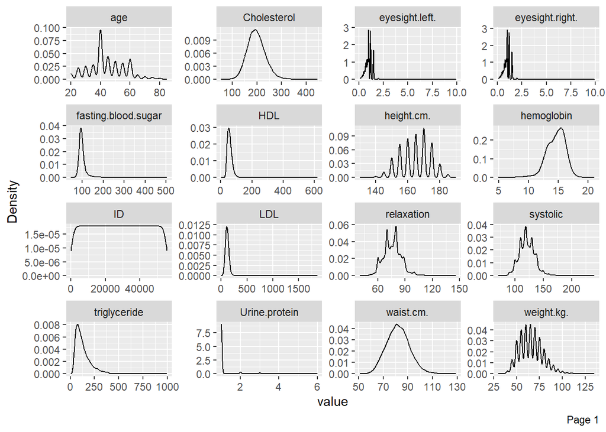

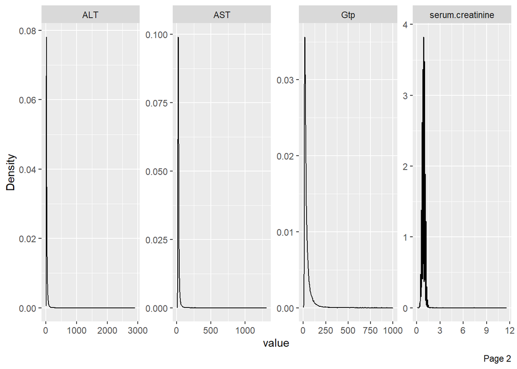

```r
plot_density(df)
```

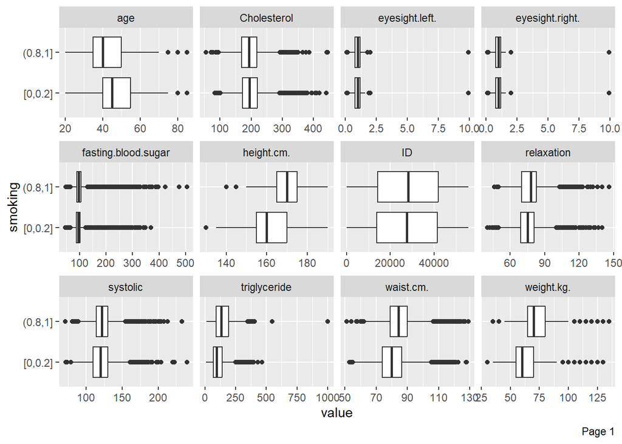

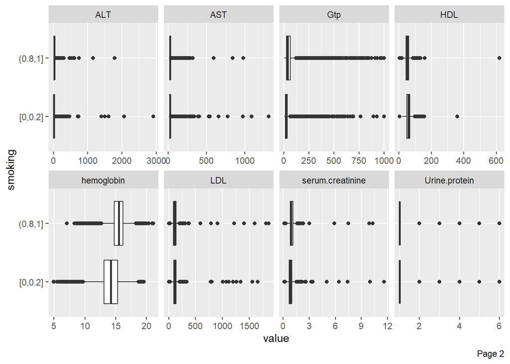

```r
plot_boxplot(df, by= 'smoking' )
```

The bar plots show that oral has only one input value throughout the entire dataset. Thus, this variable should be dropped. Furthermore, it is confirmed that hearing.left, hearing.right, dental.cares and smoking have only 2 unique values. Therefore, these columns should be converted to factor data type.

From the boxplots, there are outliers in fasting blood sugar, triglyceride, HDL, LDL.

#check correlation between continuous variables

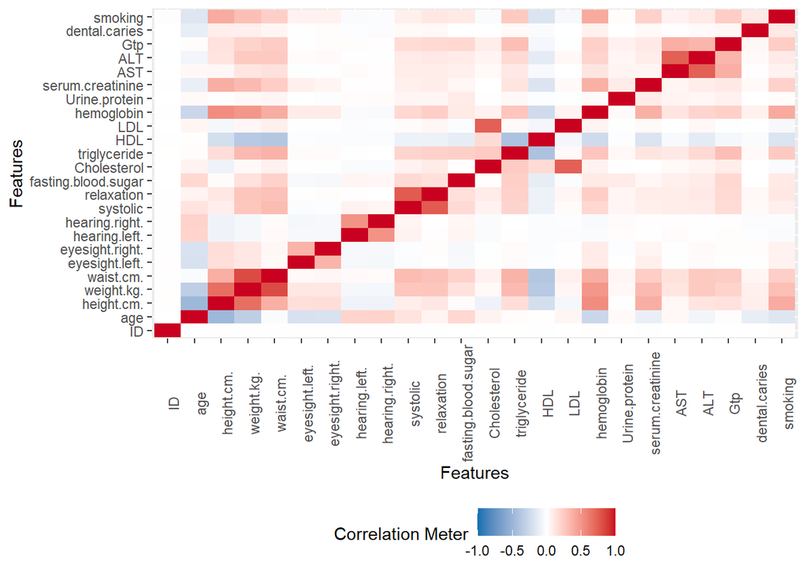

```r
plot_correlation(df,'continuous', cor_args = list("use" = "pairwise.complete.obs"))
```

#check class distribution

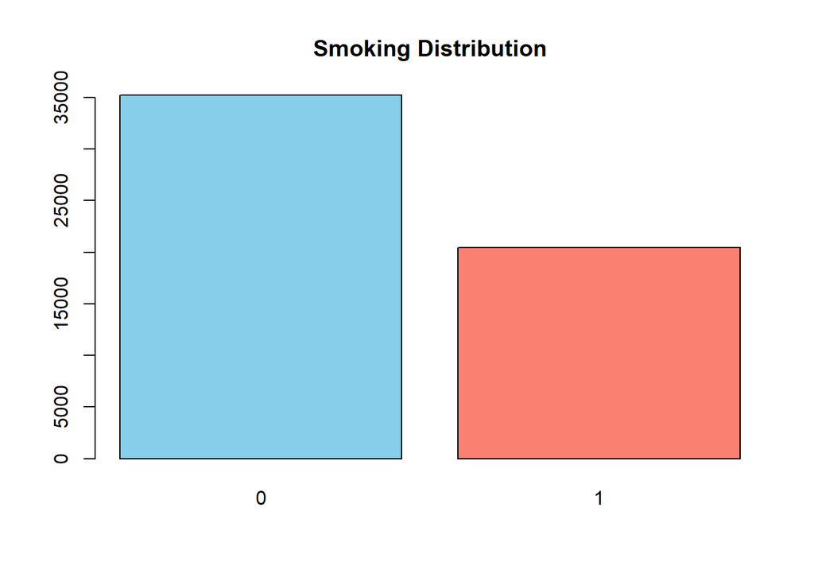

```r
barplot(table(df$smoking), main="Smoking Distribution", col=c("skyblue","salmon"))
```

```r
prop.table(table(df$smoking))
```

```
##
##         0         1
## 0.6327121 0.3672879
```

####################################Generate Missing Data for Method Exploration#######################

```r
#generate MCAR missing data

set.seed(100)
df_na<- delete_MCAR(df,0.01, c('gender', 'hemoglobin', 'ALT','serum.creatinine'))
```

#Missing Values Plot 1: Missing Data Plot with DataExplorer

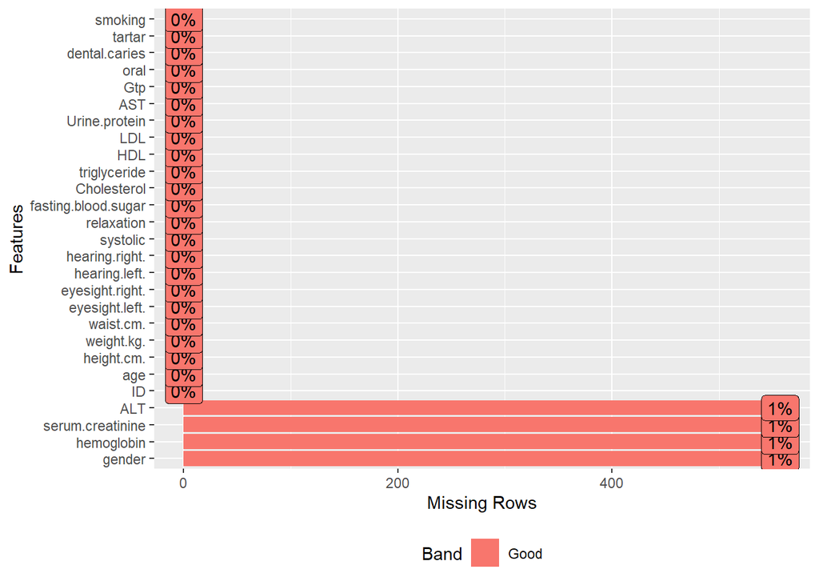

```r
#view and count missing values
plot_missing(df_na)
```

Plot 2: VIM plot

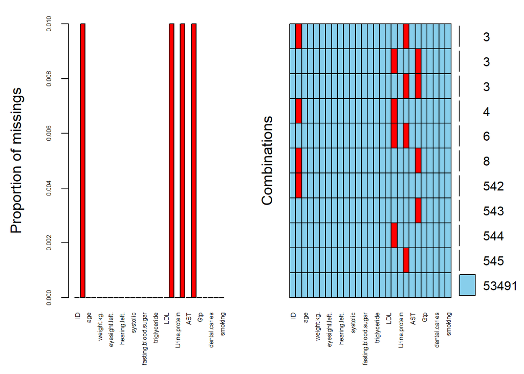

```r
vim_plot<- aggr(df_na, numbers=TRUE, prop= c(TRUE, FALSE),cex.axis=0.5)
```

******************************************Data Preparation******************************************** #Missing Data Treatment ##Imputation with missForest

Ref: https://rpubs.com/lmorgan95/MissForest#:~:text=MissForest%20is%20a%20random%20forest,then%20predicts%20the%20missing%20part. https://academic.oup.com/bioinformatics/article/28/1/112/219101 https://rstudio-pubs-static.s3.amazonaws.com/654183_b0991094b9354611b5c67ab4dbd07b04.html

#Imputation with missForest doParallel::registerDoParallel(cores = 8) # set based on number of CPU cores doRNG::registerDoRNG(seed = 123) dr <- missForest(df_na, parallelize = ‘forests’, maxiter=2, ntree=20, verbose=TRUE) imputed_df<- dr$ximp sum(is.na(imputed_df)) dr$OOBerror

#output processed data to csv file path<- ‘C:/Users/TSL/Documents/APU/Applied Machine Learning/assignment/imputed_data.csv’ write.csv(imputed_df, file=path)

```r
imputed_df<-read.csv('Imputed_data.csv',stringsAsFactors = TRUE)
```

```r
sum(is.na(imputed_df))
```

```
## [1] 0
```

#Removing the target variable. This is enable scaling of the independent variables

```r
#change column names to lower case
colnames(imputed_df)<-tolower(colnames(imputed_df))
#exclude ID, eyesight(left, right), hearing(left, right), urine.protein, dental.caries, and oral columns
imputed_df <- imputed_df %>% select(-c(x,id,eyesight.left.,eyesight.right.,hearing.left.,
        hearing.right.,urine.protein,dental.caries,oral))
#convert target variable to factor data type
imputed_df$smoking<- as.factor(imputed_df$smoking)
```

*************************************************************outliers********************************************************************** #remove outliers for fasting blood sugar, triglyceride, HDL, LDL

```r
#check which row has outliers
hdl_outlier<-imputed_df[which(imputed_df$hdl >300), ]
fbs_outlier<- imputed_df[which(imputed_df$fasting.blood.sugar>450),]
triglyceride_outlier<- imputed_df[which(imputed_df$triglyceride>500),]
chol_outlier<- imputed_df[which(imputed_df$choleterol>400),]
systolic_outlier<- imputed_df[which(imputed_df$systolic<50 & imputed_df$systolic>250),]
alt_outlier<- imputed_df[which(imputed_df$alt>500),]
ast_outlier<- imputed_df[which(imputed_df$ast>500),]
#combine all rows with outliers
outliers<-rbind(hdl_outlier,fbs_outlier,triglyceride_outlier,chol_outlier,
      systolic_outlier,alt_outlier,ast_outlier)
outliers
```

```
##        gender age height.cm. weight.kg. waist.cm. systolic relaxation
## 9223        M  35        175         80      88.0      120         80
## 44119       M  25        180         70      80.0      108         76
## 3215        M  40        175         75      88.0      114         76
## 25202       M  45        165         65      80.0      120         80
## 6443        M  45        160         70      92.0      151        100
## 32765       M  40        175         85      93.0      119         79
## 5683        F  55        145         40      73.0      100         70
## 6777        M  50        175         70      83.5      102         61
## 11012       M  35        170         75      93.0      120         80
## 11126       F  45        155         65      86.0      110         80
## 14616       M  35        170         65      86.0      124         80
## 14659       M  40        185         75      84.0      124         74
## 15497       F  55        155         55      74.0      110         70
## 15907       M  40        170         75      87.0      110         70
```

[output cut: 93 more lines]

There are 35 rows with extreme value in one of the variables hdl, triglyceride, fasting blood sugar, cholesterol,systolic, alt, ast.

```r
#remove outliers from data frame
dfclean<- anti_join(imputed_df, outliers)
```

[output not shown]

#data manipulation after removing outliers

```r
#exclude target variable
df1 <- dfclean[,-19]
#extract target variable
smoking<- dfclean[,19]
#extract numeric variables
numVar<- !sapply(df1, is.factor)
#extract factor variable
factorVar<- sapply(df1, is.factor)
#convert target variable to label for XGboost
smoking_label<- as.integer(smoking)-1
```

#peform one-hot encoding on factor variable for XGBoost model

```r
#peform one-hot encoding
one_hot<- dummify(df1[factorVar], maxcat=5L)
```

*****************************************WITH ONE-HOT ENCODING***************************************************** #combine new dataset for xgb

```r
oh_dfclean<-cbind(one_hot, df1[numVar], smoking_label)
```

#check data structure for xgb

```r
str(oh_dfclean)
```

```
## 'data.frame':    55668 obs. of  21 variables:
##  $ gender_F           : int  1 1 0 0 1 0 0 0 1 0 ...
##  $ gender_M           : int  0 0 1 1 0 1 1 1 0 1 ...
##  $ tartar_N           : int  0 0 1 0 1 0 0 0 1 1 ...
##  $ tartar_Y           : int  1 1 0 1 0 1 1 1 0 0 ...
##  $ age                : int  40 40 55 40 40 30 40 45 50 45 ...
##  $ height.cm.         : int  155 160 170 165 155 180 160 165 150 175 ...
##  $ weight.kg.         : int  60 60 60 70 60 75 60 90 60 75 ...
##  $ waist.cm.          : num  81.3 81 80 88 86 85 85.5 96 85 89 ...
##  $ systolic           : int  114 119 138 100 120 128 116 153 115 113 ...
##  $ relaxation         : int  73 70 86 60 74 76 82 96 74 64 ...
##  $ fasting.blood.sugar: int  94 130 89 96 80 95 94 158 86 94 ...
##  $ cholesterol        : int  215 192 242 322 184 217 226 222 210 198 ...
##  $ triglyceride       : int  82 115 182 254 74 199 68 269 66 147 ...
##  $ hdl                : int  73 42 55 45 62 48 55 34 48 43 ...
##  $ ldl                : int  126 127 151 226 107 129 157 134 149 126 ...
##  $ hemoglobin         : num  12.9 12.7 15.8 14.7 12.5 16.2 17 15 13.7 16 ...
##  $ serum.creatinine   : num  0.7 0.6 1 1 0.6 1.2 0.7 1.3 0.8 0.8 ...
##  $ ast                : int  18 22 21 19 16 18 21 38 31 26 ...
##  $ alt                : num  19 19 16 26 14 27 27 71 31 24 ...
##  $ gtp                : int  27 18 22 18 22 33 39 111 14 63 ...
##  $ smoking_label      : num  0 0 1 0 0 0 1 0 0 0 ...
```

#check data structure for DT and RF

```r
str(dfclean)
```

```
## 'data.frame':    55668 obs. of  19 variables:
##  $ gender             : Factor w/ 2 levels "F","M": 1 1 2 2 1 2 2 2 1 2 ...
##  $ age                : int  40 40 55 40 40 30 40 45 50 45 ...
##  $ height.cm.         : int  155 160 170 165 155 180 160 165 150 175 ...
##  $ weight.kg.         : int  60 60 60 70 60 75 60 90 60 75 ...
##  $ waist.cm.          : num  81.3 81 80 88 86 85 85.5 96 85 89 ...
##  $ systolic           : int  114 119 138 100 120 128 116 153 115 113 ...
##  $ relaxation         : int  73 70 86 60 74 76 82 96 74 64 ...
##  $ fasting.blood.sugar: int  94 130 89 96 80 95 94 158 86 94 ...
##  $ cholesterol        : int  215 192 242 322 184 217 226 222 210 198 ...
##  $ triglyceride       : int  82 115 182 254 74 199 68 269 66 147 ...
##  $ hdl                : int  73 42 55 45 62 48 55 34 48 43 ...
##  $ ldl                : int  126 127 151 226 107 129 157 134 149 126 ...
##  $ hemoglobin         : num  12.9 12.7 15.8 14.7 12.5 16.2 17 15 13.7 16 ...
##  $ serum.creatinine   : num  0.7 0.6 1 1 0.6 1.2 0.7 1.3 0.8 0.8 ...
##  $ ast                : int  18 22 21 19 16 18 21 38 31 26 ...
##  $ alt                : num  19 19 16 26 14 27 27 71 31 24 ...
##  $ gtp                : int  27 18 22 18 22 33 39 111 14 63 ...
##  $ tartar             : Factor w/ 2 levels "N","Y": 2 2 1 2 1 2 2 2 1 1 ...
##  $ smoking            : Factor w/ 2 levels "0","1": 1 1 2 1 1 1 2 1 1 1 ...
```

****************************split data into training and test sets using stratified sampling *****************************************

#split data into training and test sets

```r
#set seed to fix randomness
set.seed(123)
#split the data into training and validation sets by stratified sampling
split<- sample.split(dfclean$smoking, SplitRatio=0.7)
training<- subset(dfclean, split==TRUE)
test<- subset(dfclean, split==FALSE)
```

#split one-hot encoded data into training and test sets

```r
#set seed to fix randomness
set.seed(123)
#split the data into training and validation sets by stratified sampling
split<- sample.split(oh_dfclean$smoking, SplitRatio=0.7)
oh_training<- subset(oh_dfclean, split==TRUE)
oh_test<- subset(oh_dfclean, split==FALSE)
```

#check class distribution

```r
#data
prop.table(table(training$smoking))
```

```
##
##         0         1
## 0.6327918 0.3672082
```

```r
prop.table(table(test$smoking))
```

```
##
##         0         1
## 0.6327765 0.3672235
```

```r
#data
prop.table(table(oh_training$smoking))
```

```
##
##         0         1
## 0.6327918 0.3672082
```

```r
prop.table(table(oh_test$smoking))
```

```
##
##         0         1
## 0.6327765 0.3672235
```

***************************************************************BUILD MODELS****************************************************************************

**************************************************************DECISION TREE**************************************************************************

#Model 1: Gini Method

```r
control<- rpart.control(minsplit=2, minbucket=5, maxdepth = 8)
dt1<- rpart(smoking~ ., data=training, method='class', control=control)
dt1
```

```
## n= 38967
##
## node), split, n, loss, yval, (yprob)
##       * denotes terminal node
##
## 1) root 38967 14309 0 (0.63279185 0.36720815)
##   2) gender=F 14178   585 0 (0.95873889 0.04126111) *
##   3) gender=M 24789 11065 1 (0.44636734 0.55363266)
##     6) gtp< 28.5 10467  4660 0 (0.55479125 0.44520875) *
##     7) gtp>=28.5 14322  5258 1 (0.36712750 0.63287250) *
```

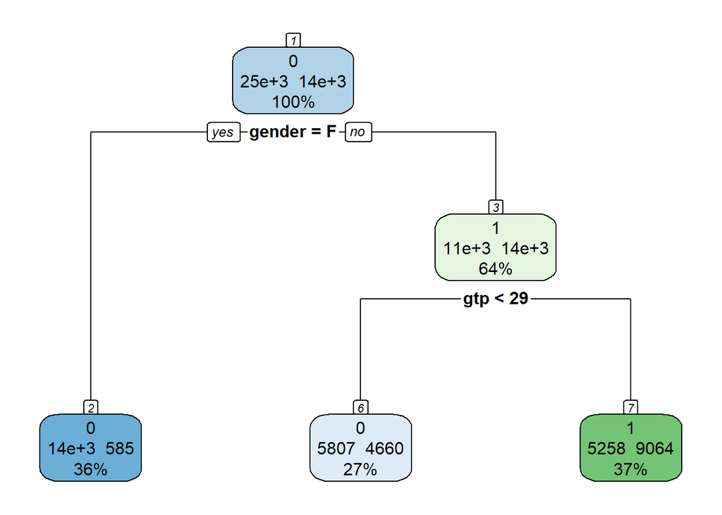

```r
rpart.plot(dt1, extra=101, nn=TRUE)
```

```r
summary(dt1)
```

```
## Call:
## rpart(formula = smoking ~ ., data = training, method = "class",
##     control = control)
##   n= 38967
##
##           CP nsplit rel error    xerror        xstd
## 1 0.18582710      0 1.0000000 1.0000000 0.006650064
## 2 0.08015934      1 0.8141729 0.8141729 0.006315703
## 3 0.01000000      2 0.7340136 0.7362499 0.006127216
##
## Variable importance
##           gender       height.cm.       hemoglobin       weight.kg.
##               27               19               18               13
## serum.creatinine              gtp              alt              ast
##               11               10                1                1
##     triglyceride
##                1
##
## Node number 1: 38967 observations,    complexity param=0.1858271
##   predicted class=0  expected loss=0.3672082  P(node) =1
##     class counts: 24658 14309
##    probabilities: 0.633 0.367
##   left son=2 (14178 obs) right son=3 (24789 obs)
##   Primary splits:
##       gender     splits as  LR,           improve=4735.622, (0 missing)
##       height.cm. < 162.5    to the left,  improve=2949.612, (0 missing)
##       hemoglobin < 14.4425  to the left,  improve=2814.021, (0 missing)
##       gtp        < 25.5     to the left,  improve=1935.656, (0 missing)
##       weight.kg. < 62.5     to the left,  improve=1543.113, (0 missing)
##   Surrogate splits:
##       height.cm.       < 162.5    to the left,  agree=0.883, adj=0.679, (0 split)
##       hemoglobin       < 14.1875  to the left,  agree=0.875, adj=0.658, (0 split)
##       weight.kg.       < 57.5     to the left,  agree=0.803, adj=0.458, (0 split)
##       serum.creatinine < 0.828125 to the left,  agree=0.786, adj=0.413, (0 split)
##       gtp              < 17.5     to the left,  agree=0.735, adj=0.270, (0 split)
##
## Node number 2: 14178 observations
##   predicted class=0  expected loss=0.04126111  P(node) =0.3638463
##     class counts: 13593   585
##    probabilities: 0.959 0.041
```

[output cut: 13 more lines]

```
##       alt          < 21.925   to the left,  agree=0.707, adj=0.306, (0 split)
##       ast          < 22.5     to the left,  agree=0.670, adj=0.218, (0 split)
##       triglyceride < 104.5    to the left,  agree=0.667, adj=0.211, (0 split)
##       waist.cm.    < 79.95    to the left,  agree=0.647, adj=0.164, (0 split)
##       relaxation   < 69.5     to the left,  agree=0.610, adj=0.077, (0 split)
##
## Node number 6: 10467 observations
##   predicted class=0  expected loss=0.4452088  P(node) =0.2686119
##     class counts:  5807  4660
##    probabilities: 0.555 0.445
##
## Node number 7: 14322 observations
##   predicted class=1  expected loss=0.3671275  P(node) =0.3675418
##     class counts:  5258  9064
##    probabilities: 0.367 0.633
```

```r
#print and plot the cp values of the model
printcp(dt1)
```

```
##
## Classification tree:
## rpart(formula = smoking ~ ., data = training, method = "class",
##     control = control)
##
## Variables actually used in tree construction:
## [1] gender gtp
##
## Root node error: 14309/38967 = 0.36721
##
## n= 38967
##
##         CP nsplit rel error  xerror      xstd
## 1 0.185827      0   1.00000 1.00000 0.0066501
## 2 0.080159      1   0.81417 0.81417 0.0063157
## 3 0.010000      2   0.73401 0.73625 0.0061272
```

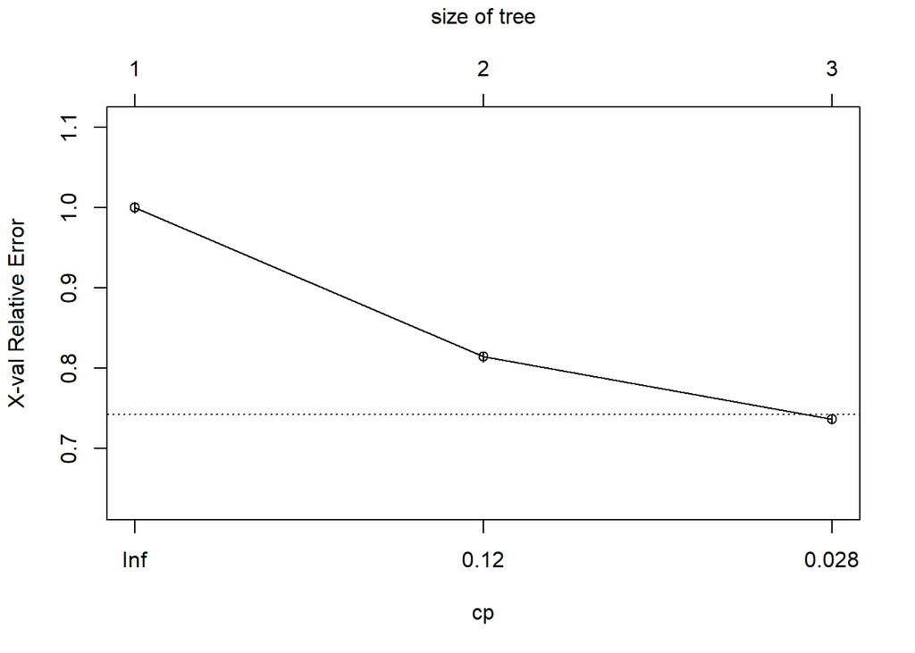

```r
plotcp(dt1)
```

#Create Prediction and Model Evaluation Functions to be called

```r
#function for prediction and confusion matrix
modelCM<-function(model, data){
  set.seed(100)
  pred<- predict(model,data[,-19], type='class')
  confusionMatrix(pred, data$smoking)
}

#function for ROC plot and AUC
ROCauc<- function (model, data){
  set.seed(100)
  pred_ROC= predict(model, type='prob', data[,-19])[,2]
  pred= prediction(pred_ROC, data$smoking)
  perf= performance(pred,'tpr', 'fpr')
  plot(perf, colorize=T,
       main='ROC Curve',
       ylab= 'Sensitivity',
       xlab= 'Specificity',
       print.cutoffs.at=seq(0,1,0.3),
       text.adj= c(-0.2,1.7))
  auc= as.numeric(performance(pred, 'auc')@y.values)
  auc=round(auc,3)
  print(paste('AUC:', auc))
}
```

#predict and evaluate on training set

```r
#confusion matrix for evaluation
modelCM(dt1, training)
```

```
## Confusion Matrix and Statistics
##
##           Reference
## Prediction     0     1
##          0 19400  5245
##          1  5258  9064
##
##                Accuracy : 0.7305
##                  95% CI : (0.726, 0.7349)
##     No Information Rate : 0.6328
##     P-Value [Acc > NIR] : <2e-16
##
##                   Kappa : 0.4201
##
##  Mcnemar's Test P-Value : 0.9068
##
##             Sensitivity : 0.7868
##             Specificity : 0.6334
##          Pos Pred Value : 0.7872
##          Neg Pred Value : 0.6329
##              Prevalence : 0.6328
##          Detection Rate : 0.4979
##    Detection Prevalence : 0.6325
##       Balanced Accuracy : 0.7101
##
##        'Positive' Class : 0
##
```

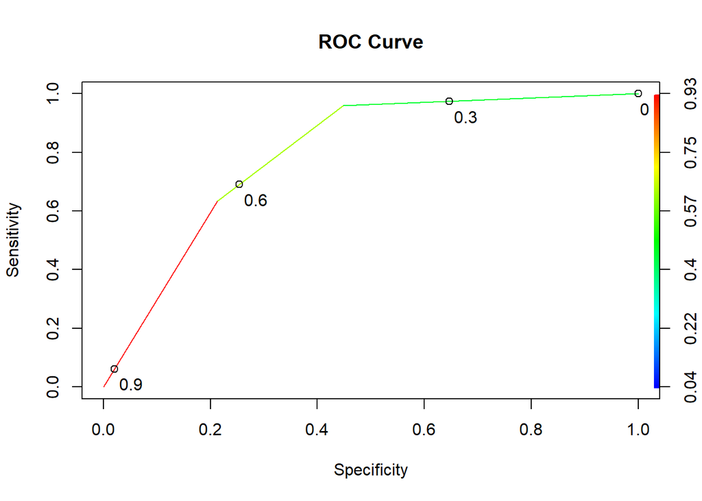

```
## [1] "AUC: 0.795"
```

```r
#ROC curve
ROCauc(dt1, training)
```

#call functions to predict and evaluate on test set

```r
#confusion matrix for evaluation
modelCM(dt1, test)
```

```
## Confusion Matrix and Statistics
##
##           Reference
## Prediction    0    1
##          0 8311 2313
##          1 2257 3820
##
##                Accuracy : 0.7264
##                  95% CI : (0.7195, 0.7331)
##     No Information Rate : 0.6328
##     P-Value [Acc > NIR] : <2e-16
##
##                   Kappa : 0.4101
##
##  Mcnemar's Test P-Value : 0.4159
##
##             Sensitivity : 0.7864
##             Specificity : 0.6229
##          Pos Pred Value : 0.7823
##          Neg Pred Value : 0.6286
##              Prevalence : 0.6328
##          Detection Rate : 0.4976
##    Detection Prevalence : 0.6361
##       Balanced Accuracy : 0.7046
##
##        'Positive' Class : 0
##
```

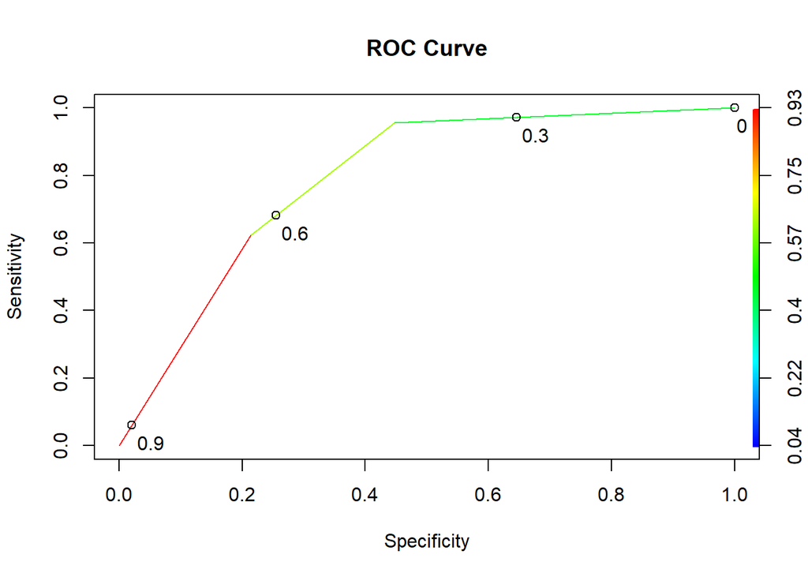

```
## [1] "AUC: 0.792"
```

```r
#ROC curve
ROCauc(dt1, test)
```

#variable importance

```r
sort(dt1$variable.importance)
```

```
##       relaxation        waist.cm.     triglyceride              ast
##         33.00322         69.66894         89.89410         92.86479
##              alt              gtp serum.creatinine       weight.kg.
##        130.18163       1706.55101       1954.30411       2168.40579
##       hemoglobin       height.cm.           gender
##       3113.99371       3213.19527       4735.62189
```

#Model 2: Entropy method

```r
# Split with entropy information
control<- rpart.control(minsplit=2, minbucket=5, maxdepth = 8)
dt2 = rpart(smoking ~ ., data=training, method="class", parms=list(split="information"), control=control)
dt2
```

```
## n= 38967
##
## node), split, n, loss, yval, (yprob)
##       * denotes terminal node
##
## 1) root 38967 14309 0 (0.63279185 0.36720815)
##   2) gender=F 14178   585 0 (0.95873889 0.04126111) *
##   3) gender=M 24789 11065 1 (0.44636734 0.55363266)
##     6) gtp< 28.5 10467  4660 0 (0.55479125 0.44520875) *
##     7) gtp>=28.5 14322  5258 1 (0.36712750 0.63287250) *
```

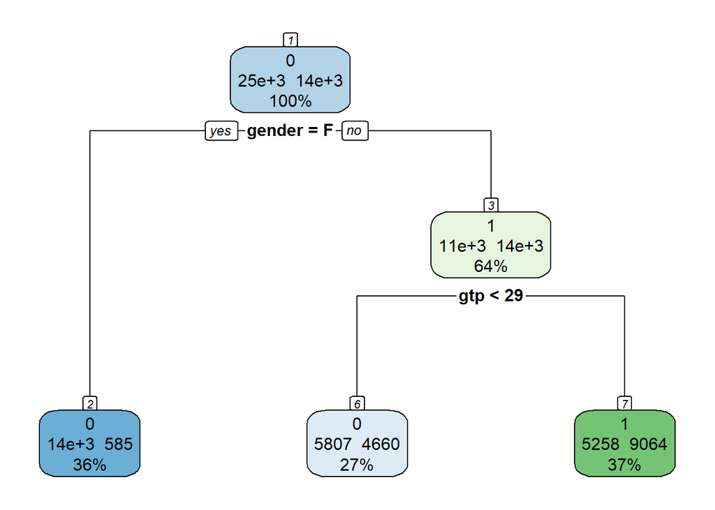

```r
rpart.plot(dt2, extra = 101, nn = TRUE)
```

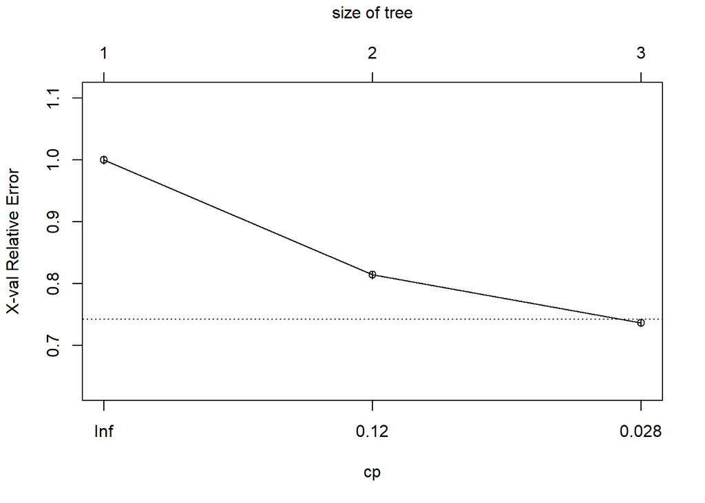

```r
plotcp(dt2)
```

```r
printcp(dt2)
```

```
##
## Classification tree:
## rpart(formula = smoking ~ ., data = training, method = "class",
##     parms = list(split = "information"), control = control)
##
## Variables actually used in tree construction:
## [1] gender gtp
##
## Root node error: 14309/38967 = 0.36721
##
## n= 38967
##
##         CP nsplit rel error  xerror      xstd
## 1 0.185827      0   1.00000 1.00000 0.0066501
## 2 0.080159      1   0.81417 0.81417 0.0063157
## 3 0.010000      2   0.73401 0.73604 0.0061267
```

#predict and evaluate entropy model on training data

```r
#confusion matrix for evaluation
modelCM(dt2, training)
```

```
## Confusion Matrix and Statistics
##
##           Reference
## Prediction     0     1
##          0 19400  5245
##          1  5258  9064
##
##                Accuracy : 0.7305
##                  95% CI : (0.726, 0.7349)
##     No Information Rate : 0.6328
##     P-Value [Acc > NIR] : <2e-16
##
##                   Kappa : 0.4201
##
##  Mcnemar's Test P-Value : 0.9068
##
##             Sensitivity : 0.7868
##             Specificity : 0.6334
##          Pos Pred Value : 0.7872
##          Neg Pred Value : 0.6329
##              Prevalence : 0.6328
##          Detection Rate : 0.4979
##    Detection Prevalence : 0.6325
##       Balanced Accuracy : 0.7101
##
##        'Positive' Class : 0
##
```

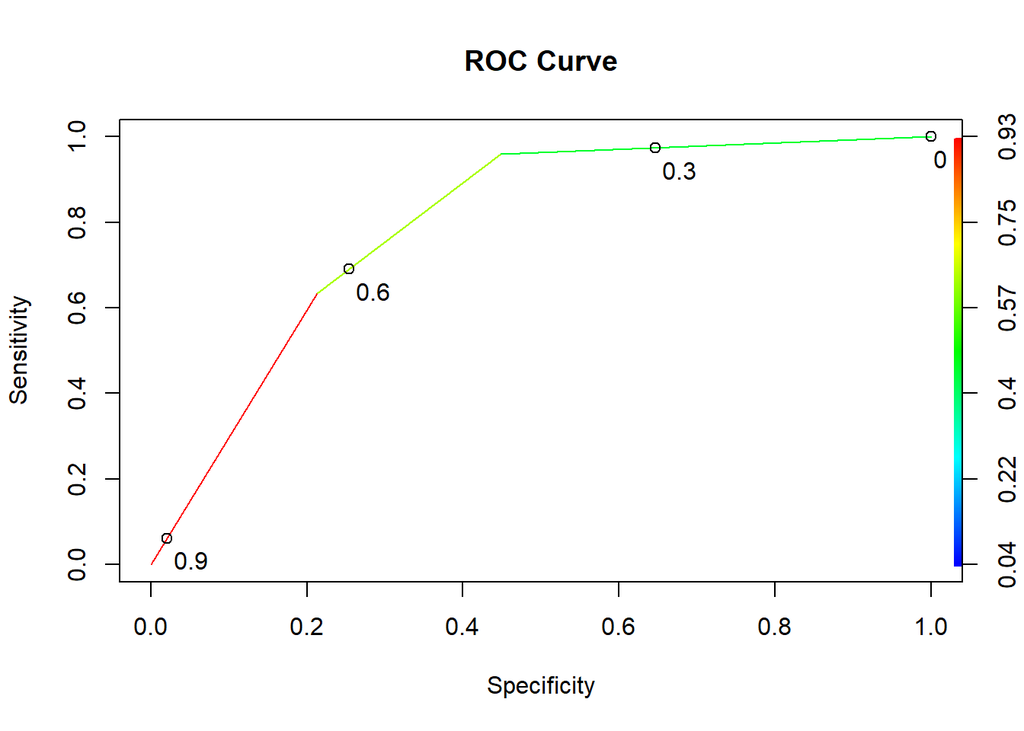

```
## [1] "AUC: 0.795"
```

```r
#ROC curve
ROCauc(dt2, training)
```

#predict and evaluate model on test set

```r
#confusion matrix for evaluation
modelCM(dt2, test)
```

```
## Confusion Matrix and Statistics
##
##           Reference
## Prediction    0    1
##          0 8311 2313
##          1 2257 3820
##
##                Accuracy : 0.7264
##                  95% CI : (0.7195, 0.7331)
##     No Information Rate : 0.6328
##     P-Value [Acc > NIR] : <2e-16
##
##                   Kappa : 0.4101
##
##  Mcnemar's Test P-Value : 0.4159
##
##             Sensitivity : 0.7864
##             Specificity : 0.6229
##          Pos Pred Value : 0.7823
##          Neg Pred Value : 0.6286
##              Prevalence : 0.6328
##          Detection Rate : 0.4976
##    Detection Prevalence : 0.6361
##       Balanced Accuracy : 0.7046
##
##        'Positive' Class : 0
##
```

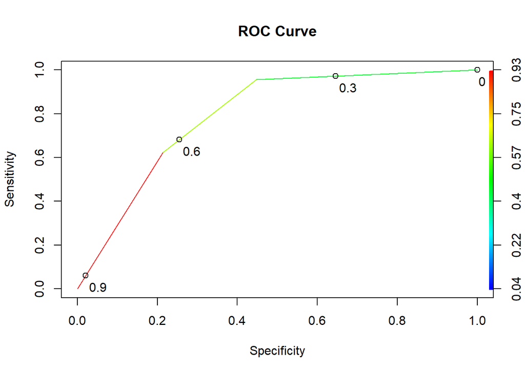

```
## [1] "AUC: 0.792"
```

```r
#ROC curve
ROCauc(dt2, test)
```

#variable importance

```r
sort(dt2$variable.importance)
```

```
##       relaxation        waist.cm.     triglyceride              ast
##         33.46646         70.64683         91.15587         94.16826
##              alt              gtp serum.creatinine       weight.kg.
##        132.00888       2092.78356       2534.60279       2812.27847
##       hemoglobin       height.cm.           gender
##       4038.64328       4167.30112       6141.78745
```

#TUNING #Model 3: Pruning using CV

```r
#check for best cp through cross validation
set.seed(100)
val_control= rpart.control(minsplit=2, minbucket=5, maxdepth = 8,cp=0, xval=10)
dt_cv = rpart(smoking ~ ., data=training, method="class", parms=list(split="gini"), control=val_control)
summary(dt_cv)
```

```
## Call:
## rpart(formula = smoking ~ ., data = training, method = "class",
##     parms = list(split = "gini"), control = val_control)
##   n= 38967
##
##              CP nsplit rel error    xerror        xstd
## 1  1.858271e-01      0 1.0000000 1.0000000 0.006650064
## 2  8.015934e-02      1 0.8141729 0.8141729 0.006315703
## 3  7.244858e-03      2 0.7340136 0.7360403 0.006126667
## 4  2.795443e-03      5 0.7122790 0.7140261 0.006067683
## 5  2.620728e-03      7 0.7066881 0.7113705 0.006060389
## 6  2.079111e-03      9 0.7014466 0.7070375 0.006048407
## 7  1.840334e-03     16 0.6815291 0.7011671 0.006032008
## 8  1.817038e-03     19 0.6760081 0.7022154 0.006034950
## 9  1.747152e-03     20 0.6741911 0.7001188 0.006029059
## 10 1.490903e-03     21 0.6724439 0.6983717 0.006024131
## 11 1.397722e-03     25 0.6663638 0.6950171 0.006014621
## 12 1.327836e-03     26 0.6649661 0.6950171 0.006014621
## 13 1.188063e-03     27 0.6636383 0.6943881 0.006012831
## 14 7.687469e-04     28 0.6624502 0.6922916 0.006006848
## 15 6.639178e-04     31 0.6601440 0.6908240 0.006002646
## 16 5.940317e-04     33 0.6588161 0.6918722 0.006005649
## 17 5.590887e-04     37 0.6564400 0.6948075 0.006014025
## 18 4.892026e-04     38 0.6558809 0.6954364 0.006015814
## 19 4.193165e-04     39 0.6553917 0.6964148 0.006018591
## 20 4.076688e-04     44 0.6532951 0.6972535 0.006020968
## 21 3.843735e-04     50 0.6508491 0.6975330 0.006021759
## 22 3.494304e-04     52 0.6500804 0.6979523 0.006022946
## 23 3.144874e-04     54 0.6493815 0.6982319 0.006023736
## 24 2.795443e-04     56 0.6487525 0.7001188 0.006029059
## 25 2.096583e-04     59 0.6479139 0.6997694 0.006028075
## 26 1.630675e-04     68 0.6460270 0.6989307 0.006025710
## 27 1.537494e-04     71 0.6455378 0.6990006 0.006025907
## 28 1.397722e-04     76 0.6447690 0.6996995 0.006027878
## 29 6.988609e-05     77 0.6446293 0.7005381 0.006030239
## 30 6.670945e-05     83 0.6442099 0.7026347 0.006036125
## 31 5.241456e-05    110 0.6421832 0.7028444 0.006036713
## 32 3.494304e-05    114 0.6419736 0.7032637 0.006037886
## 33 0.000000e+00    122 0.6416940 0.7046614 0.006041792
##
```

[output cut: 2632 more lines]

[output not shown]

```r
#print and plot the cp values of the model
printcp(dt_cv)
```

```
##
## Classification tree:
## rpart(formula = smoking ~ ., data = training, method = "class",
##     parms = list(split = "gini"), control = val_control)
##
## Variables actually used in tree construction:
##  [1] age                 alt                 ast
##  [4] cholesterol         fasting.blood.sugar gender
##  [7] gtp                 hdl                 height.cm.
## [10] hemoglobin          ldl                 relaxation
## [13] serum.creatinine    systolic            tartar
## [16] triglyceride        waist.cm.           weight.kg.
##
## Root node error: 14309/38967 = 0.36721
##
```

[output cut: 36 more lines]

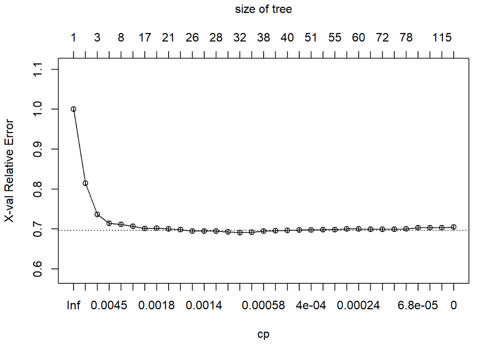

```r
plotcp(dt_cv)
```

```r
bestcp=dt_cv$cptable[which.min(dt_cv$cptable[,"xerror"]),"CP"]
bestcp
```

```
## [1] 0.0006639178
```

#Model 3 prune the tree with the best cp

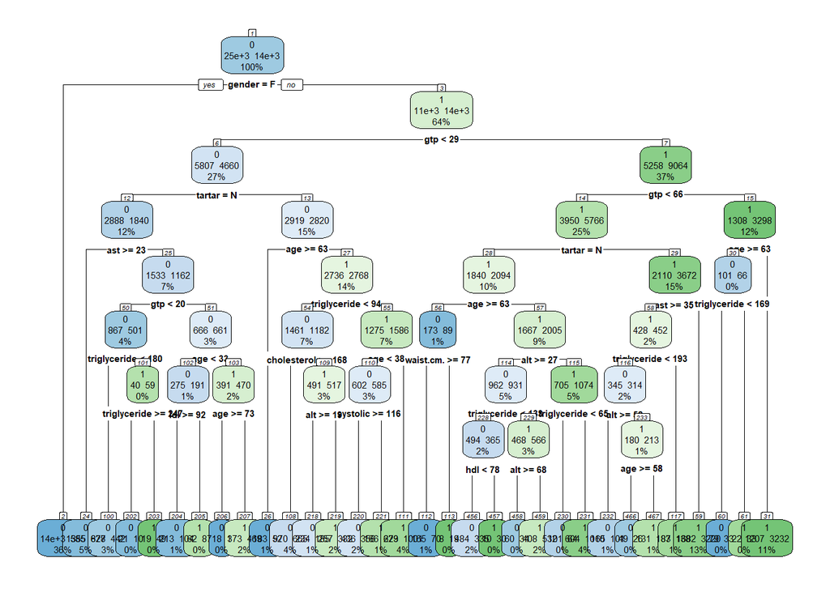

```r
#prune the tree using the best cp
dt3<-prune(dt_cv, cp=bestcp)
#plot pruned tree
rpart.plot(dt3, extra=101, nn=TRUE, tweak=2.3, varlen=0, faclen = 0)
```

```r
#confusion matrix for evaluation
modelCM(dt3, training)
```

```
## Confusion Matrix and Statistics
##
##           Reference
## Prediction     0     1
##          0 18953  3741
##          1  5705 10568
##
##                Accuracy : 0.7576
##                  95% CI : (0.7533, 0.7618)
##     No Information Rate : 0.6328
##     P-Value [Acc > NIR] : < 2.2e-16
##
##                   Kappa : 0.493
##
##  Mcnemar's Test P-Value : < 2.2e-16
##
##             Sensitivity : 0.7686
##             Specificity : 0.7386
##          Pos Pred Value : 0.8352
##          Neg Pred Value : 0.6494
##              Prevalence : 0.6328
##          Detection Rate : 0.4864
##    Detection Prevalence : 0.5824
##       Balanced Accuracy : 0.7536
##
##        'Positive' Class : 0
##
```

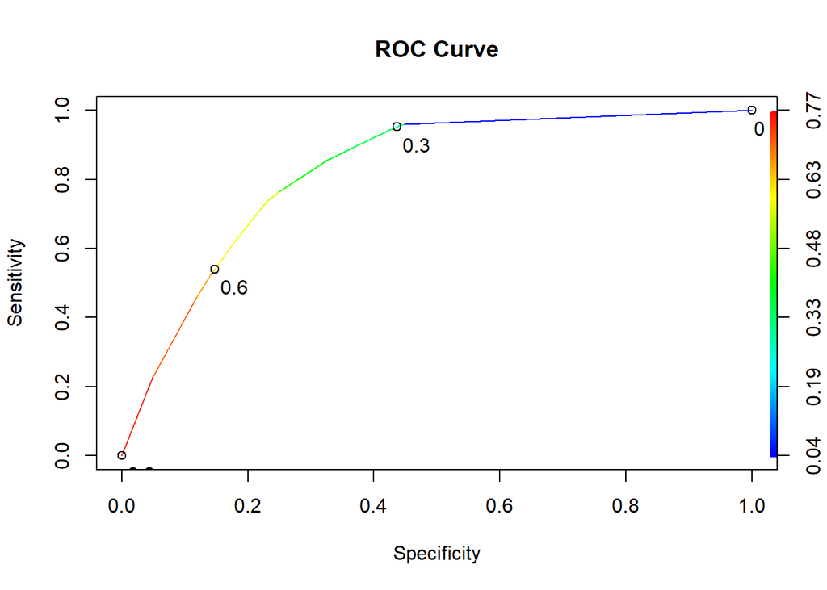

```
## [1] "AUC: 0.825"
```

```r
#ROC curve
ROCauc(dt3, training)
```

```r
#confusion matrix for evaluation
modelCM(dt3, test)
```

```
## Confusion Matrix and Statistics
##
##           Reference
## Prediction    0    1
##          0 8032 1715
##          1 2536 4418
##
##                Accuracy : 0.7455
##                  95% CI : (0.7388, 0.7521)
##     No Information Rate : 0.6328
##     P-Value [Acc > NIR] : < 2.2e-16
##
##                   Kappa : 0.4673
##
##  Mcnemar's Test P-Value : < 2.2e-16
##
##             Sensitivity : 0.7600
##             Specificity : 0.7204
##          Pos Pred Value : 0.8240
##          Neg Pred Value : 0.6353
##              Prevalence : 0.6328
##          Detection Rate : 0.4809
##    Detection Prevalence : 0.5836
##       Balanced Accuracy : 0.7402
##
##        'Positive' Class : 0
##
```

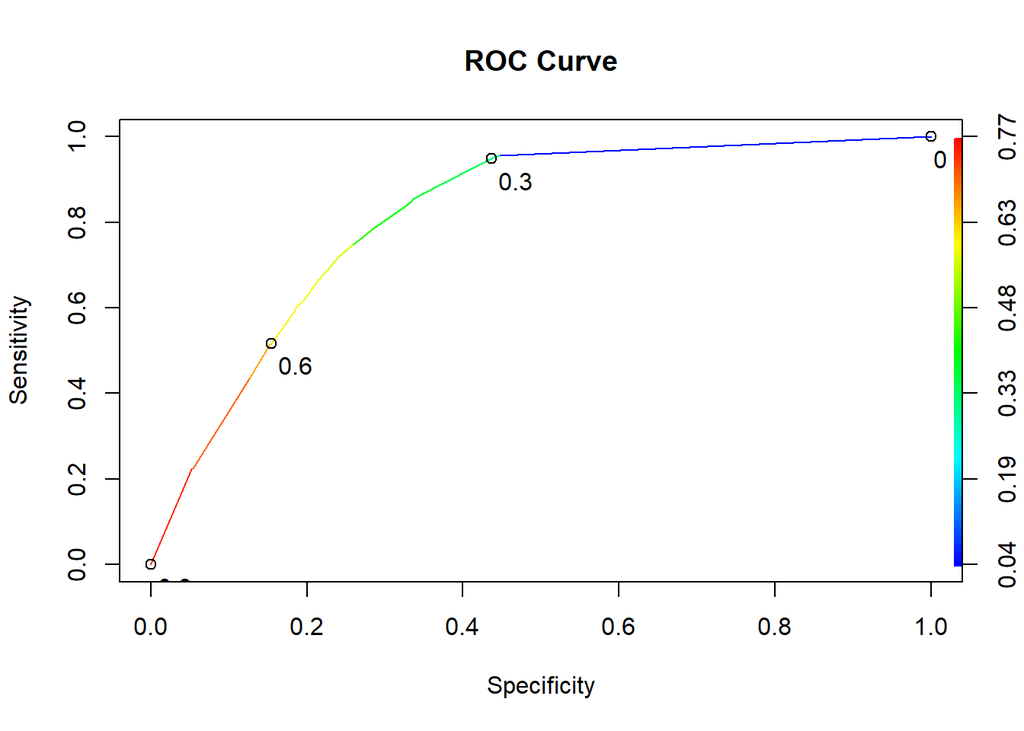

```
## [1] "AUC: 0.814"
```

```r
#ROC curve
ROCauc(dt3, test)
```

#variable importance

```r
sort(dt3$variable.importance)
```

```
## fasting.blood.sugar            systolic                 ldl         cholesterol
##            5.356853           10.794755           23.993588           31.859980
##                 hdl          relaxation           waist.cm.              tartar
##           32.419802           36.907645           95.143922          103.630554
##                 age                 ast        triglyceride                 alt
##          145.646158          173.515868          193.356228          209.791288
##                 gtp    serum.creatinine          weight.kg.          hemoglobin
##         1835.722886         1955.386496         2179.710252         3115.067940
##          height.cm.              gender
##         3216.687274         4735.621889
```

```r
#random forest best model
pred_ROC= predict(dt3, type='prob', test[,-19])[,2]
pred_pruneddt= prediction(pred_ROC, test$smoking)
```

#compare models

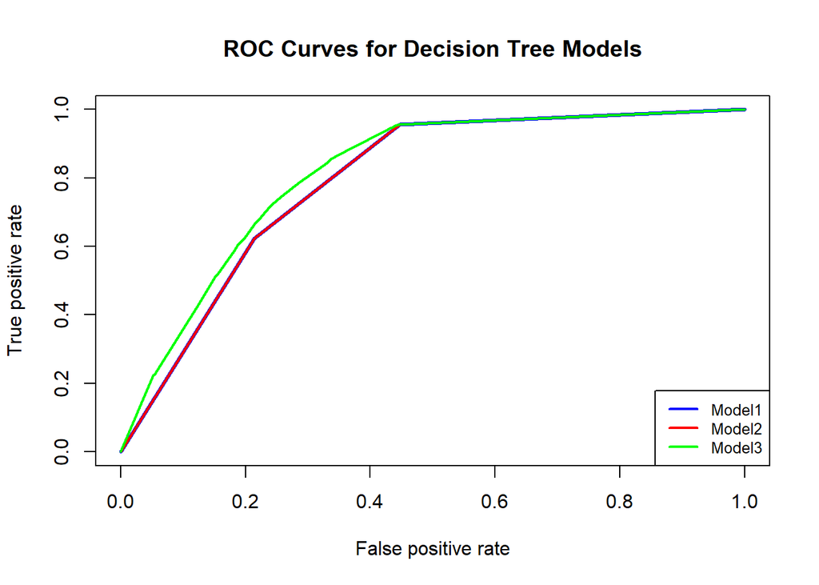

```r
dt1_pred_prob<- predict(dt1, type='prob', test[, -19])[,2]
dt1_pred<- prediction(dt1_pred_prob,test$smoking)
dt1_perf= performance(dt1_pred, 'tpr','fpr')
plot(dt1_perf, col='blue', lwd=3, main='ROC Curves for Decision Tree Models')

dt2_pred_prob<- predict(dt2, type='prob',test[, -19])[,2]
dt2_pred= prediction(dt2_pred_prob, test$smoking)
dt2_perf= performance(dt2_pred, 'tpr','fpr')
plot(dt2_perf, col='red', lwd=2, add=TRUE)

dt3_pred_prob= predict(dt3, type='prob',test[, -19])[,2]
dt3_pred= prediction(dt3_pred_prob, test$smoking)
dt3_perf= performance(dt3_pred,'tpr', 'fpr')
plot(dt3_perf, col='green', lwd=2, add=TRUE)

legend('bottomright', legend=c('Model1', 'Model2', 'Model3'), col=c('blue', 'red', 'green'), lwd=2, cex=0.8)
```

******************************************************RANDOM FOREST******************************************************

#Model 1: basic model

```r
#build basic model
library(randomForest)
set.seed(100)
rf1<- randomForest(smoking~.,data = training)
print(rf1)
```

```
##
## Call:
##  randomForest(formula = smoking ~ ., data = training)
##                Type of random forest: classification
##                      Number of trees: 500
## No. of variables tried at each split: 4
##
##         OOB estimate of  error rate: 17.75%
## Confusion matrix:
##       0     1 class.error
## 0 20778  3880   0.1573526
## 1  3036 11273   0.2121742
```

```r
#check feature importance
rf1$importance
```

```
##                     MeanDecreaseGini
## gender                     2190.2625
## age                         699.7437
## height.cm.                 1345.5960
## weight.kg.                  665.3239
## waist.cm.                   933.7774
## systolic                    847.4529
## relaxation                  789.2211
## fasting.blood.sugar         895.6121
## cholesterol                 920.5077
## triglyceride               1248.6235
## hdl                         894.3281
## ldl                         937.3383
## hemoglobin                 1623.5088
## serum.creatinine            657.5579
## ast                         799.0076
## alt                         901.7031
## gtp                        1599.2323
## tartar                      159.0346
```

#functions to be called

```r
#function for model evaluation
modelCM<-function(model, data){
  pred<- predict(model,data[,-19], type='class')
  confusionMatrix(pred, data$smoking, mode='everything')
}

#function for ROC plot and AUC
ROCauc<- function (model, data){
  pred_ROC= predict(model, data[,-19], type='prob')[,2]
  pred= prediction(pred_ROC, data$smoking)
  perf= performance(pred,'tpr', 'fpr')
  plot(perf, colorize=T,
       main='ROC Curve',
       ylab= 'Sensitivity',
       xlab= 'Specificity',
       print.cutoffs.at=seq(0,1,0.3),
       text.adj= c(-0.2,1.7))
  auc= as.numeric(performance(pred, 'auc')@y.values)
  auc=round(auc,3)
  print(paste('AUC:', auc))
}
```

#predict and evaluate model with training set

```r
modelCM(rf1, training)
```

```
## Confusion Matrix and Statistics
##
##           Reference
## Prediction     0     1
##          0 24658     0
##          1     0 14309
##
##                Accuracy : 1
##                  95% CI : (0.9999, 1)
##     No Information Rate : 0.6328
##     P-Value [Acc > NIR] : < 2.2e-16
##
##                   Kappa : 1
##
##  Mcnemar's Test P-Value : NA
##
##             Sensitivity : 1.0000
##             Specificity : 1.0000
##          Pos Pred Value : 1.0000
##          Neg Pred Value : 1.0000
##               Precision : 1.0000
##                  Recall : 1.0000
##                      F1 : 1.0000
##              Prevalence : 0.6328
##          Detection Rate : 0.6328
##    Detection Prevalence : 0.6328
##       Balanced Accuracy : 1.0000
##
##        'Positive' Class : 0
##
```

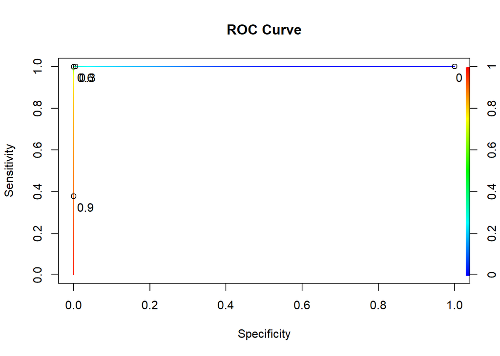

```
## [1] "AUC: 1"
```

```r
ROCauc(rf1, training)
```

Predicting using the basic random forest model yields a 100% accuracy, sensitivity, and specificity.

#predict and evaluate model with test set

```r
modelCM(rf1, test)
```

```
## Confusion Matrix and Statistics
##
##           Reference
## Prediction    0    1
##          0 8956 1343
##          1 1612 4790
##
##                Accuracy : 0.8231
##                  95% CI : (0.8172, 0.8288)
##     No Information Rate : 0.6328
##     P-Value [Acc > NIR] : < 2.2e-16
##
##                   Kappa : 0.6228
##
##  Mcnemar's Test P-Value : 8.219e-07
##
##             Sensitivity : 0.8475
##             Specificity : 0.7810
##          Pos Pred Value : 0.8696
##          Neg Pred Value : 0.7482
##               Precision : 0.8696
##                  Recall : 0.8475
##                      F1 : 0.8584
##              Prevalence : 0.6328
##          Detection Rate : 0.5363
##    Detection Prevalence : 0.6167
##       Balanced Accuracy : 0.8142
##
##        'Positive' Class : 0
##
```

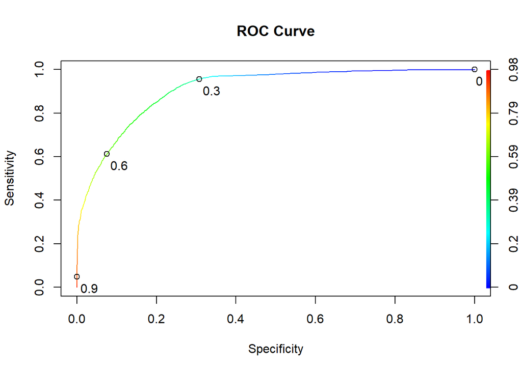

```
## [1] "AUC: 0.91"
```

```r
ROCauc(rf1, test)
```

Model 2, ntree=2000 In RF model, multiple hyperparameters can be tuned to increase performance of the model. These include ntree (the number of trees in the forest), mtry (the number of variables randomly selected at each split, mtry is the sqrt of number of features when performing classification), nodesize (maximum number size of terminal nodes. Large number causes smaller trees to be grown).maxnodes (the maximum number of terminal nodes in the forest).

Different approaches of tuning the hyperparameter is available. The following approach uses tuneRF function to determine the best mtry hyperparmeter.

```r
#build basic model
library(randomForest)
set.seed(100)
rf2<- randomForest(smoking~.,data = training, ntree=2000)
print(rf2)
```

```
##
## Call:
##  randomForest(formula = smoking ~ ., data = training, ntree = 2000)
##                Type of random forest: classification
##                      Number of trees: 2000
## No. of variables tried at each split: 4
##
##         OOB estimate of  error rate: 17.59%
## Confusion matrix:
##       0     1 class.error
## 0 20786  3872   0.1570281
## 1  2982 11327   0.2084003
```

```r
#check number of trees built
rf2$ntree
```

```
## [1] 2000
```

```r
#check feature importance
rf2$importance
```

```
##                     MeanDecreaseGini
## gender                     2233.1362
## age                         697.4044
## height.cm.                 1288.9701
## weight.kg.                  678.9644
## waist.cm.                   927.1367
## systolic                    844.1326
## relaxation                  790.0545
## fasting.blood.sugar         895.3368
## cholesterol                 919.5156
## triglyceride               1259.1056
## hdl                         892.9635
## ldl                         935.1808
## hemoglobin                 1605.6559
## serum.creatinine            658.3296
## ast                         800.9415
## alt                         906.3522
## gtp                        1617.5057
## tartar                      159.0594
```

#predict and evaluate model with training set

```r
modelCM(rf2, training)
```

```
## Confusion Matrix and Statistics
##
##           Reference
## Prediction     0     1
##          0 24658     0
##          1     0 14309
##
##                Accuracy : 1
##                  95% CI : (0.9999, 1)
##     No Information Rate : 0.6328
##     P-Value [Acc > NIR] : < 2.2e-16
##
##                   Kappa : 1
##
##  Mcnemar's Test P-Value : NA
##
##             Sensitivity : 1.0000
##             Specificity : 1.0000
##          Pos Pred Value : 1.0000
##          Neg Pred Value : 1.0000
##               Precision : 1.0000
##                  Recall : 1.0000
##                      F1 : 1.0000
##              Prevalence : 0.6328
##          Detection Rate : 0.6328
##    Detection Prevalence : 0.6328
##       Balanced Accuracy : 1.0000
##
##        'Positive' Class : 0
##
```

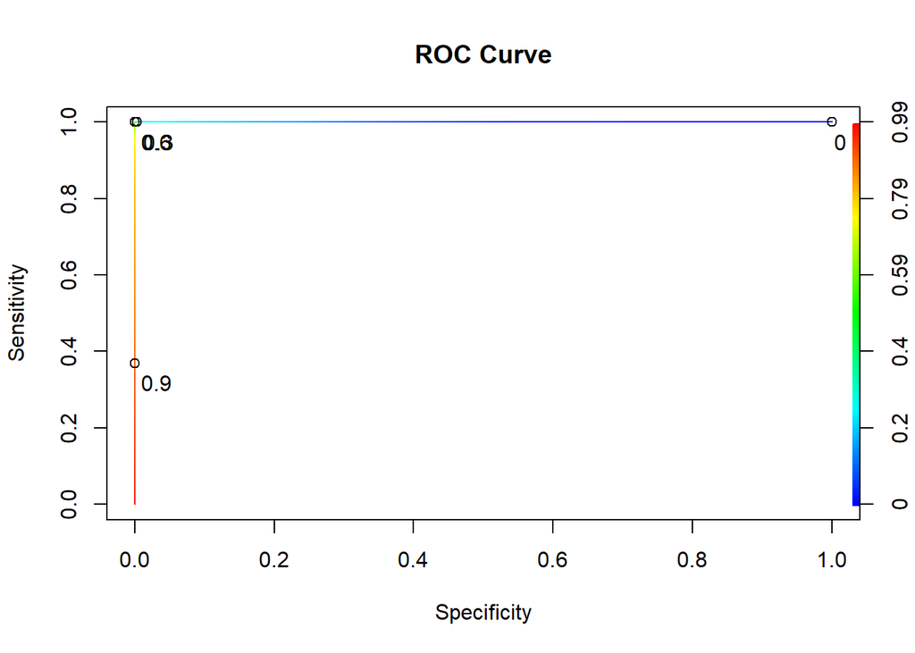

```
## [1] "AUC: 1"
```

```r
ROCauc(rf2, training)
```

Predicting using the basic random forest model yields a 100% accuracy, sensitivity, and specificity.

#predict and evaluate model with test set

```r
modelCM(rf2, test)
```

```
## Confusion Matrix and Statistics
##
##           Reference
## Prediction    0    1
##          0 8959 1324
##          1 1609 4809
##
##                Accuracy : 0.8244
##                  95% CI : (0.8185, 0.8301)
##     No Information Rate : 0.6328
##     P-Value [Acc > NIR] : < 2.2e-16
##
##                   Kappa : 0.6258
##
##  Mcnemar's Test P-Value : 1.571e-07
##
##             Sensitivity : 0.8477
##             Specificity : 0.7841
##          Pos Pred Value : 0.8712
##          Neg Pred Value : 0.7493
##               Precision : 0.8712
##                  Recall : 0.8477
##                      F1 : 0.8593
##              Prevalence : 0.6328
##          Detection Rate : 0.5364
##    Detection Prevalence : 0.6157
##       Balanced Accuracy : 0.8159
##
##        'Positive' Class : 0
##
```

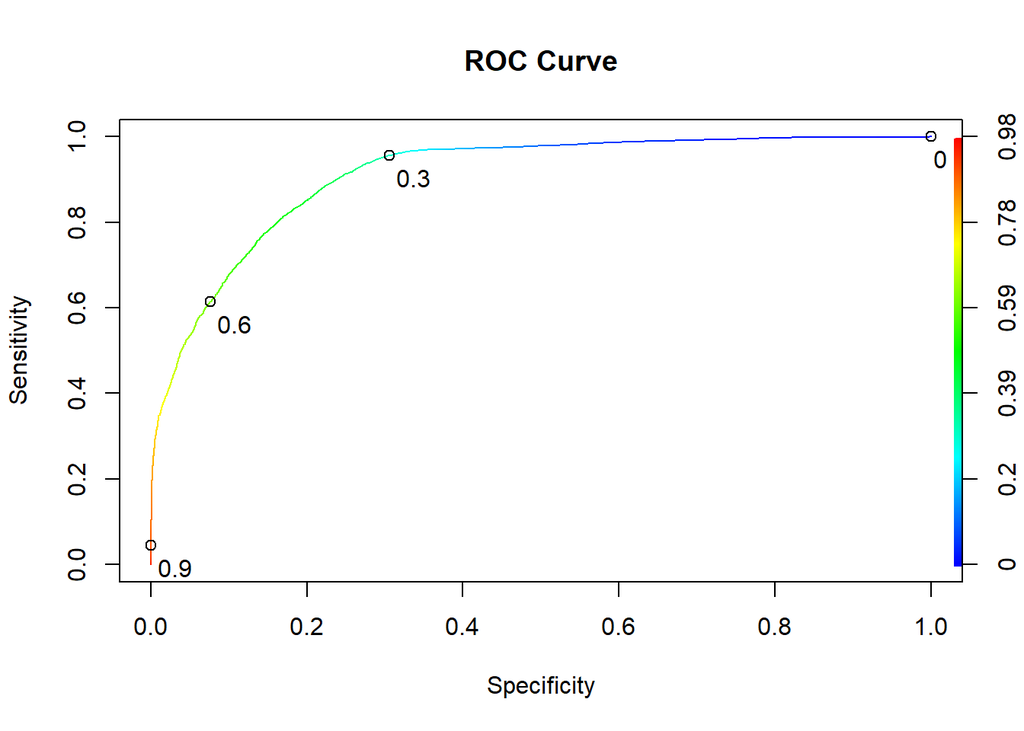

```
## [1] "AUC: 0.91"
```

```r
ROCauc(rf2, test)
```

#Model 3: Tune mtry #use tuneRF to determine hyperparameter mtry

```
## mtry = 4  OOB error = 17.59%
## Searching left ...
## mtry = 3     OOB error = 17.53%
## 0.003647505 1e-05
## mtry = 2     OOB error = 17.55%
## -0.001610778 1e-05
## Searching right ...
## mtry = 6     OOB error = 17.54%
## -0.0008786059 1e-05
```

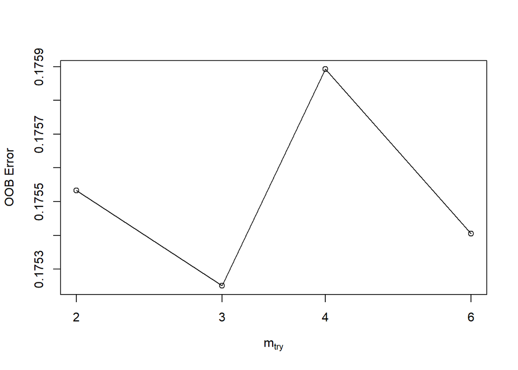

```r
set.seed(100)
mtry <- tuneRF(training[-19],training$smoking,
               ntreeTry=2000,
               stepFactor=1.5,
               improve=1e-5,
               trace=TRUE,
               plot=TRUE)
```

```r
best.m <- mtry[mtry[, 2] == min(mtry[, 2]), 1]
print(mtry)
```

```
##       mtry  OOBError
## 2.OOB    2 0.1755331
## 3.OOB    3 0.1752509
## 4.OOB    4 0.1758924
## 6.OOB    6 0.1754048
```

```r
print(best.m)
```

```
## [1] 3
```

#train model using the best mtry on training data

```r
set.seed(100)
rf3<-randomForest(smoking~., data=training,
                  mtry=3, ntree=2000)
print(rf3)
```

```
##
## Call:
##  randomForest(formula = smoking ~ ., data = training, mtry = 3,      ntree = 2000)
##                Type of random forest: classification
##                      Number of trees: 2000
## No. of variables tried at each split: 3
##
##         OOB estimate of  error rate: 17.47%
## Confusion matrix:
##       0     1 class.error
## 0 20806  3852   0.1562170
## 1  2954 11355   0.2064435
```

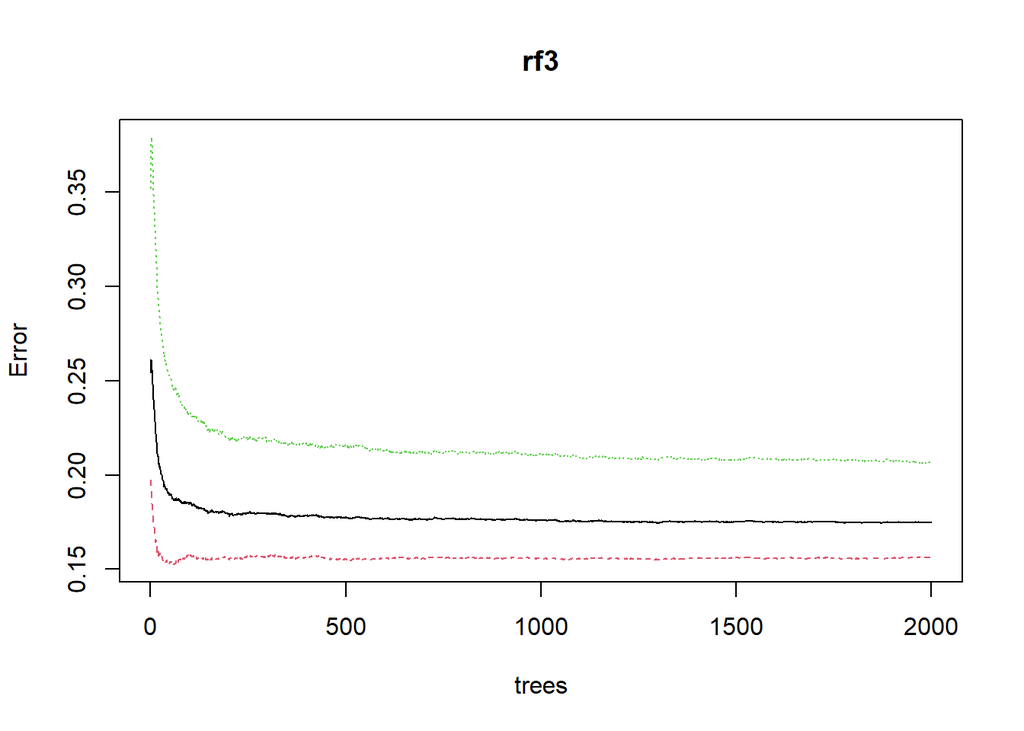

```r
plot(rf3)
```

#predict and evaluate on training data

```r
modelCM(rf3,training)
```

```
## Confusion Matrix and Statistics
##
##           Reference
## Prediction     0     1
##          0 24658     0
##          1     0 14309
##
##                Accuracy : 1
##                  95% CI : (0.9999, 1)
##     No Information Rate : 0.6328
##     P-Value [Acc > NIR] : < 2.2e-16
##
##                   Kappa : 1
##
##  Mcnemar's Test P-Value : NA
##
##             Sensitivity : 1.0000
##             Specificity : 1.0000
##          Pos Pred Value : 1.0000
##          Neg Pred Value : 1.0000
##               Precision : 1.0000
##                  Recall : 1.0000
##                      F1 : 1.0000
##              Prevalence : 0.6328
##          Detection Rate : 0.6328
##    Detection Prevalence : 0.6328
##       Balanced Accuracy : 1.0000
##
##        'Positive' Class : 0
##
```